# Comparing Gat201-dependent and Rim101-dependent gene expression

Edward Wallace

2023-04-23

Compare Gat201-dependent and Rim101-dependent gene expression.

Using:

- RIM101 DEGs in Dulbecco’s modified Eagle’s medium [DMEM] with 5% CO2 at 37°C from [O’Meara et al 2013](https://doi.org/10.1128/mBio.00522-12)
- GAT201 DEGs also in DMEM with 5% CO2 at 37°C [Homer et al 2016](http://dx.doi.org/10.1016/j.chom.2016.05.001)
- GAT201 DEGs at 4h in RPMI from this study.

Overall, this finds by eyeballing the numbers that there is no evidence for enrichment of RIM101 targets in GAT201 targets or vice versa. This analysis is rough because the datasets are from 3 different studies and analysed in rather different ways. However, in the absence of evidence in favour of overlap from here or elsewhere it’s a reasonable start.

Also RIM101 is not in the GAT201-dependent list, and vice versa.

## Load data, RIM101 and GAT201 in DMEM

```r
RIM101_DEGs_DMEM <-
  here::here("data_external",
             "OMeara2013_TableS3_Rim101_DEGs_mbo006121415st3.xlsx") %>%
  readxl::read_excel(col_names = c("gene", "lnFC", "Annotation","GO_function", "GO_process", "GO_component"),
                     skip = 1)

RIM101_DEGs_DMEM
```

```
## # A tibble: 1,257 × 6
##    gene         lnFC Annotation    GO_function       GO_process     GO_component
##    <chr>       <dbl> <chr>         <chr>             <chr>          <chr>
##  1 CNAG_00006  1.40  prohibitin P… null              null           null
##  2 CNAG_00013  1.43  predicted pr… null              null           null
##  3 CNAG_00020 -0.799 conserved hy… null              null           null
##  4 CNAG_00026 -1.86  aminotransfe… pyridoxal phosph… biosynthetic … null
##  5 CNAG_00034 -1.03  60s ribosoma… rRNA binding str… translation    ribosome
##  6 CNAG_00036  0.890 Sec14 cytoso… null              null           null
##  7 CNAG_00044 -1.20  translation … GTP binding GTPa… null           null
##  8 CNAG_00047  0.990 kinase        ATP binding prot… peptidyl-hist… null
##  9 CNAG_00051 -1.32  conserved hy… DNA binding prot… null           null
## 10 CNAG_00054  1.83  DUF1264 doma… null              null           null
## # … with 1,247 more rows
```

```r
GAT201_DEGs_DMEM <-
  here::here("data_external",
             "Homer2016_TableS1_ChIPSeq.xls") %>%
  readxl::read_excel(sheet = "Gat201 RNA Data",
                     col_names = c("gene", "log2FC_Rep1", "log2FC_Rep2","log2FC_mean", "ChIP_enrichment"),
                     skip = 1)

GAT201_DEGs_DMEM
```

```
## # A tibble: 7,823 × 5
##    gene       log2FC_Rep1 log2FC_Rep2 log2FC_mean ChIP_enrichment
##    <chr>            <dbl>       <dbl>       <dbl>           <dbl>
##  1 CNAG_00001     -0.689      -1.19        -0.917           NA
##  2 CNAG_00002     -0.827       0.0371      -0.331           NA
##  3 CNAG_00003     -0.307      -0.346       -0.327           NA
##  4 CNAG_00004     -0.178      -0.0750      -0.125           NA
##  5 CNAG_00005     -1.18       -2.60        -1.73             4.50
##  6 CNAG_00006      0.0850     -0.368       -0.124           NA
##  7 CNAG_00007      0.271       0.0582       0.169           NA
##  8 CNAG_00008      0.678       0.291        0.497           NA
##  9 CNAG_00009      0.703       0.733        0.719            2.73
## 10 CNAG_00010      1.20        1.25         1.22             3.02
## # … with 7,813 more rows
```

Confirm Gat201 isn’t in the RIM101-DEG list and vice versa

```r
"CNAG_01551" %in% RIM101_DEGs_DMEM$gene
```

```
## [1] FALSE
```

```r
"CNAG_05431" %in% dplyr::filter(GAT201_DEGs_DMEM, abs(log2FC_mean) > 1)$gene
```

```
## [1] FALSE
```

## Compare RIM101 and GAT201 in DMEM

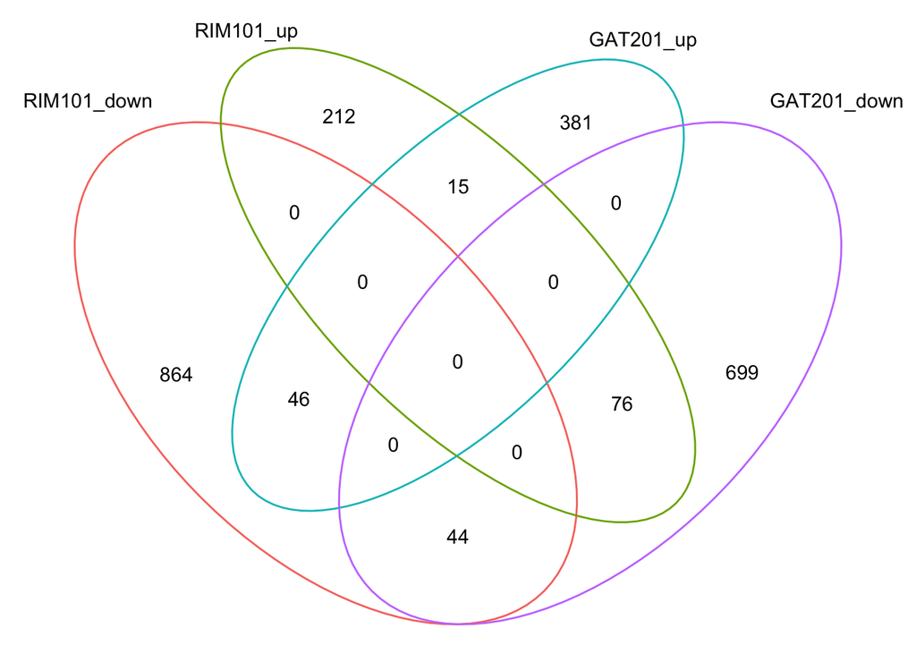

```r
vennplotdata <-
  list("RIM101_down" = RIM101_DEGs_DMEM  %>%
         dplyr::filter(lnFC < 0 ) %>%
         dplyr::pull(gene),
         "RIM101_up" = RIM101_DEGs_DMEM  %>%
         dplyr::filter(lnFC > 0 ) %>%
         dplyr::pull(gene),
       "GAT201_up" = GAT201_DEGs_DMEM  %>%
         dplyr::filter(log2FC_mean > 1 ) %>%
         dplyr::pull(gene),
       "GAT201_down" = GAT201_DEGs_DMEM  %>%
         dplyr::filter(log2FC_mean < -1 ) %>%
         dplyr::pull(gene)
  ) %>%
  RVenn::Venn() %>%
  ggVennDiagram::process_data()

venn_RIM101_vs_GAT201_DMEM <-
  ggplot() +
  geom_sf(aes(color = id),
          data = ggVennDiagram::venn_setedge(vennplotdata), show.legend = FALSE) +
  geom_sf_text(aes(label = name),
               data = ggVennDiagram::venn_setlabel(vennplotdata)) +
  geom_sf_text(aes(label = count),
               data = ggVennDiagram::venn_region(vennplotdata)) +
  theme_void() +
  # scale_colour_manual(values = c("grey20", "darkred", "darkblue")) +
  coord_sf(clip = "off")

venn_RIM101_vs_GAT201_DMEM
```

Comparing these numbers with the total number of genes (7823 in the GAT201 list) - it’s clear that there is no statistical enrichment for RIM101 DEGs in GAT201 DEGS or vice versa. No connection.

## Compare GAT201 RPMI with GAT201 DMEM

```r
GAT201_down_RPMI4h <-
  here::here("results", "DEGids_RPMI_240_vsGAT201_down2x_FDR5.txt") %>%
  read_lines()

GAT201_up_RPMI4h <-
  here::here("results", "DEGids_RPMI_240_vsGAT201_up2x_FDR5.txt") %>%
  read_lines()
```

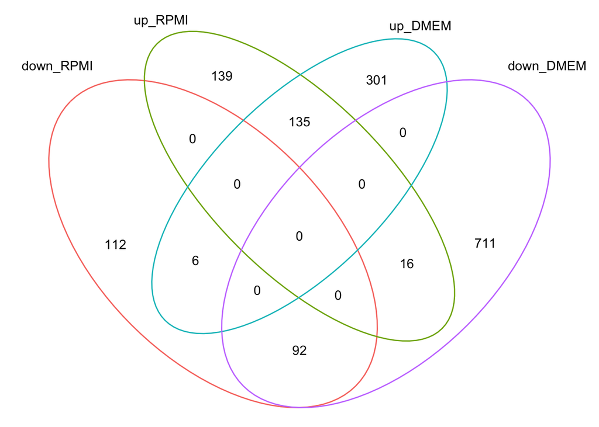

```r
vennplotdata <-
  list("down_RPMI" = GAT201_down_RPMI4h,
       "up_RPMI"   = GAT201_up_RPMI4h,
       "up_DMEM"   = GAT201_DEGs_DMEM  %>%
         dplyr::filter(log2FC_mean > 1 ) %>%
         dplyr::pull(gene),
       "down_DMEM" = GAT201_DEGs_DMEM  %>%
         dplyr::filter(log2FC_mean < -1 ) %>%
         dplyr::pull(gene)
  ) %>%
  RVenn::Venn() %>%
  ggVennDiagram::process_data()

venn_GAT201_RPMI_vs_GAT201_DMEM <-
  ggplot() +
  geom_sf(aes(color = id),
          data = ggVennDiagram::venn_setedge(vennplotdata), show.legend = FALSE) +
  geom_sf_text(aes(label = name),
               data = ggVennDiagram::venn_setlabel(vennplotdata)) +
  geom_sf_text(aes(label = count),
               data = ggVennDiagram::venn_region(vennplotdata)) +
  theme_void() +
  # scale_colour_manual(values = c("grey20", "darkred", "darkblue")) +
  coord_sf(clip = "off")

venn_GAT201_RPMI_vs_GAT201_DMEM
```

This is reasonable. About half the Gat201-regulated genes in RPMI (FDR 5%, 2x enriched) are regulated in the same direction in DMEM (2x mean, no FDR control).

## Compare GAT201 RPMI with RIM101 DMEM

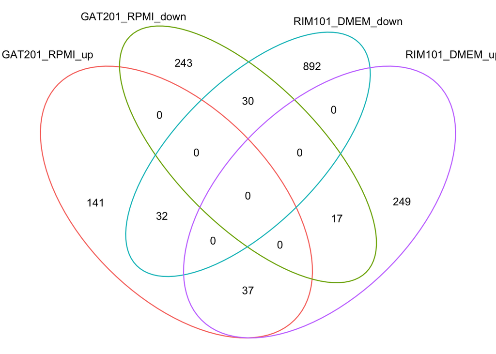

```r
vennplotdata <-
  list("GAT201_RPMI_up"   = GAT201_down_RPMI4h,
       "GAT201_RPMI_down" = GAT201_up_RPMI4h,
       "RIM101_DMEM_down" = RIM101_DEGs_DMEM  %>%
         dplyr::filter(lnFC < 0 ) %>%
         dplyr::pull(gene),
       "RIM101_DMEM_up"   = RIM101_DEGs_DMEM  %>%
         dplyr::filter(lnFC > 0 ) %>%
         dplyr::pull(gene)
  ) %>%
  RVenn::Venn() %>%
  ggVennDiagram::process_data()

venn_GAT201_RPMI_vs_RIM101_DMEM <-
  ggplot() +
  geom_sf(aes(color = id),
          data = ggVennDiagram::venn_setedge(vennplotdata), show.legend = FALSE) +
  geom_sf_text(aes(label = name),
               data = ggVennDiagram::venn_setlabel(vennplotdata)) +
  geom_sf_text(aes(label = count),
               data = ggVennDiagram::venn_region(vennplotdata)) +
  theme_void() +
  # scale_colour_manual(values = c("grey20", "darkred", "darkblue")) +
  coord_sf(clip = "off")

venn_GAT201_RPMI_vs_RIM101_DMEM
```

Again, the overlap is low. Low enough that it’s a waste of time to do any statistical tests to look for more: no evidence for overlapping targets of GAT201 and RIM101.